# Polimetrics 2022

## 3. Statistical Summaries

### Keywords in Context

Find keywords in context and plot lexical dispersion (position of words within documents).

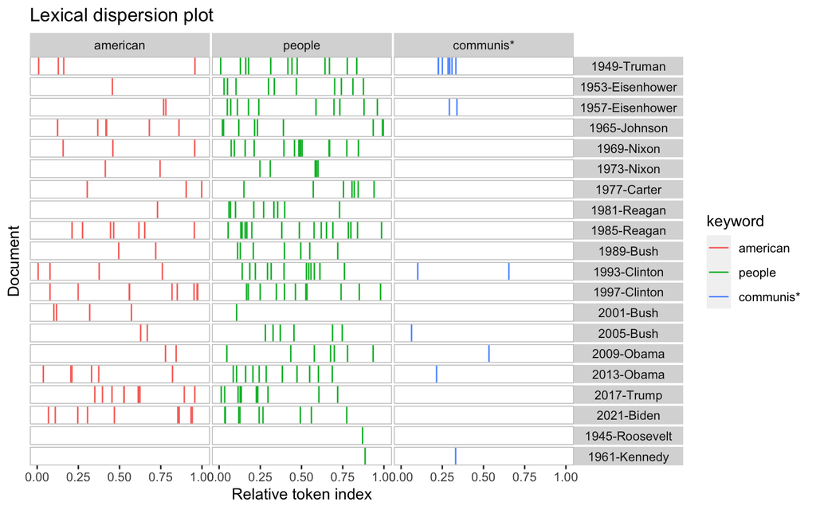

```r
## kwic (keywords in context)
# by single word or pattern
kwic(tokens(data_corpus_inaugural), "terror*", window = 5)
## Keyword-in-context with 12 matches.
##     [1797-Adams, 1324]                   fraud or violence, by |  terror   |
##  [1933-Roosevelt, 111]      nameless, unreasoning, unjustified |  terror   |
##  [1941-Roosevelt, 285]           seemed frozen by a fatalistic |  terror   |
##    [1961-Kennedy, 850]         alter that uncertain balance of |  terror   |
##    [1961-Kennedy, 972]               of science instead of its |  terrors  |
##     [1981-Reagan, 811]          freeing all Americans from the |  terror   |
##    [1981-Reagan, 2186]        understood by those who practice | terrorism |
##   [1997-Clinton, 1047]             They fuel the fanaticism of |  terror   |
##   [1997-Clinton, 1647]       maintain a strong defense against |  terror   |
##     [2009-Obama, 1619]          advance their aims by inducing |  terror   |
##     [2017-Trump, 1117] civilized world against radical Islamic | terrorism |
##      [2021-Biden, 544]             , white supremacy, domestic | terrorism |
##
##  , intrigue, or venality
##  which paralyzes needed efforts to
##  , we proved that this
##  that stays the hand of
##  . Together let us explore
##  of runaway living costs.
##  and prey upon their neighbors
##  . And they torment the
##  and destruction. Our children
##  and slaughtering innocents, we
##  , which we will eradicate
##  that we must confront and
# by phrase
kwic(tokens(data_corpus_inaugural), phrase("by terror"), window = 5)
## Keyword-in-context with 1 match.
##  [1797-Adams, 1323:1324] by fraud or violence, | by terror |
##
##  , intrigue, or venality

# plotting kwic as a lexical dispersion plot (ggplot object)
library(quanteda.textplots)
textplot_xray(
  kwic(tokens(data_corpus_inaugural[40:59]), "american"),
  kwic(tokens(data_corpus_inaugural[40:59]), "people"),
  kwic(tokens(data_corpus_inaugural[40:59]), "communis*")
) +
  aes(color = keyword)
```

### Tagcloud

Plot words in a word cloud based on their frequency.

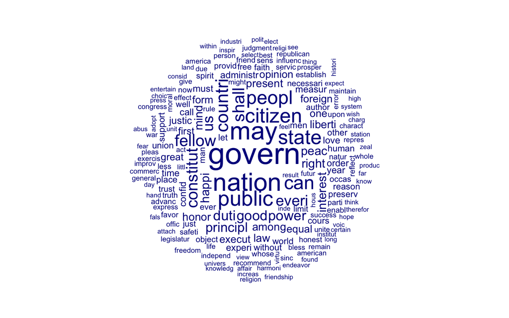

```r
# tagcloud
textplot_wordcloud(speeches_dfm, min_count = 5)
```

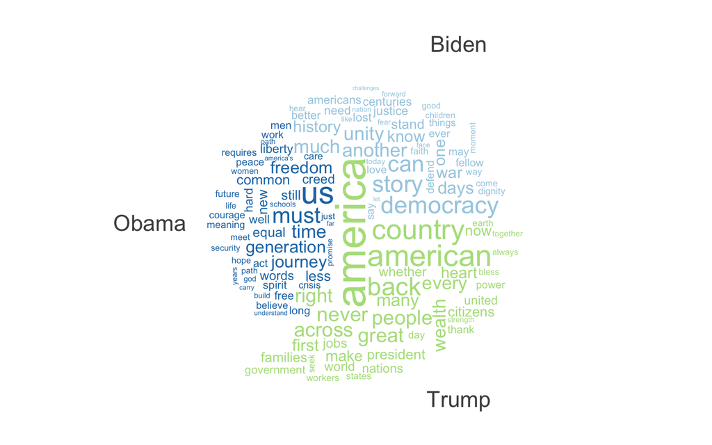

```r
# preprocessing
recent_presidents_corpus <- corpus_subset(data_corpus_inaugural,
                                          President %in% c("Biden", "Trump", "Obama"))
recent_presidents_tokens <- tokens(recent_presidents_corpus,
                                   remove_punct = TRUE,
                                   remove_numbers=TRUE,
                                   remove_symbols = TRUE,
                                   split_hyphens = TRUE,
                                   remove_separators = TRUE)
recent_presidents_tokens <- tokens_remove(recent_presidents_tokens, stopwords("en"))
recent_presidents_dfm <- dfm(recent_presidents_tokens)
recent_presidents_dfm <- dfm_group(recent_presidents_dfm, groups = President)
recent_presidents_dfm <- dfm_trim(recent_presidents_dfm, min_termfreq = 6)
# plotting
textplot_wordcloud(recent_presidents_dfm, comparison = TRUE)
```

### Lexical Diversity

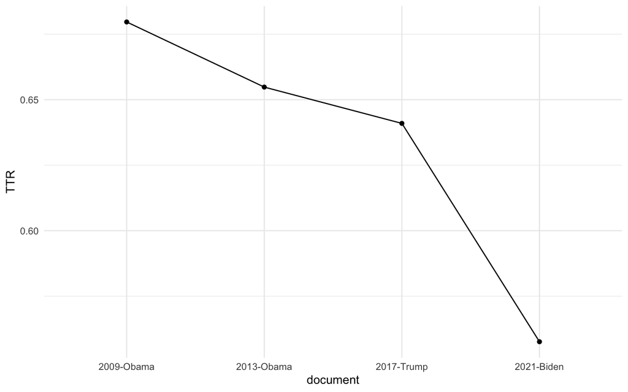

```r
# lexical diversity
recent_presidents_corpus <- corpus_subset(data_corpus_inaugural,
                                          President %in% c("Biden", "Trump", "Obama"))
recent_presidents_tokens <- tokens(recent_presidents_corpus,
                                   remove_punct = TRUE,
                                   remove_numbers=TRUE,
                                   remove_symbols = TRUE,
                                   split_hyphens = TRUE,
                                   remove_separators = TRUE)
recent_presidents_tokens <- tokens_remove(recent_presidents_tokens, stopwords("en"))
recent_presidents_dfm <- dfm(recent_presidents_tokens)
speeches_lexdiv <- textstat_lexdiv(recent_presidents_dfm)

# plot
ggplot(speeches_lexdiv) +
  aes(x=document, y=TTR, group=1) +
  geom_line() +
  geom_point() +
  theme_minimal()
```

### Target Group vs Reference Group

More sophisticated methods compare the differential occurrences of words across texts or partitions of a corpus, using statistical association measures, to identify the words that belong for example to different sub-groups of texts, such as those predominantly associated for example with male - versus female - authored documents. We can use a [chi-squared test](http://www.luigicurini.com/uploads/6/7/9/8/67985527/lab_1_extra_a_2022_chi2_extra.pdf) for such comparisons to see if their is a statistically significant difference.

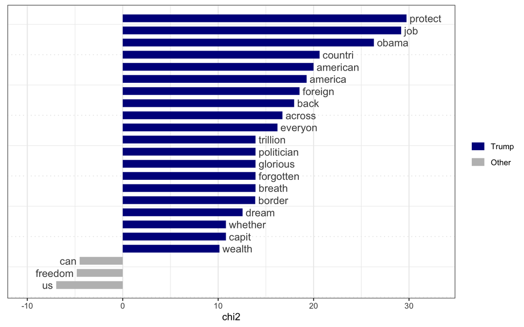

```r
# prepare corpus
GOP_corpus <- corpus_subset(data_corpus_inaugural, Year > 1946 & Party== "Republican")
GOP_corpus$Trump <- ifelse(GOP_corpus$President=="Trump", "Trump", "Other")
GOP_tokens <- tokens(GOP_corpus,
                     remove_punct = TRUE,
                     remove_numbers=TRUE,
                     remove_symbols = TRUE,
                     split_hyphens = TRUE,
                     remove_separators = TRUE)
GOP_tokens <- tokens_remove(GOP_tokens, stopwords("en"))
GOP_tokens_stemmed <- tokens_wordstem(GOP_tokens)
GOP_dfm <- dfm(GOP_tokens_stemmed)
GOP_Trump_dfm <- dfm_group(GOP_dfm, groups = Trump)
# find similarity between Trump and other GOP presidents
GOP_Trump_keyness <- textstat_keyness(GOP_Trump_dfm , target = "Trump")
# keep only significant values
GOP_Trump_keyness <- GOP_Trump_keyness[GOP_Trump_keyness$p <= 0.05, ]
# plot
textplot_keyness(GOP_Trump_keyness)
```

### Cosine Similarity

[Cosine similarity](http://www.luigicurini.com/uploads/6/7/9/8/67985527/lab_1_extra_b_2022_cosine_similarity_extra.pdf) is an intuitive measure of semantic similarity. More in details, the cosine similarity between two texts ranges between 0 and 1, where 0 is reached when two texts are completely different and 1 is reached when two texts have identical feature proportions.

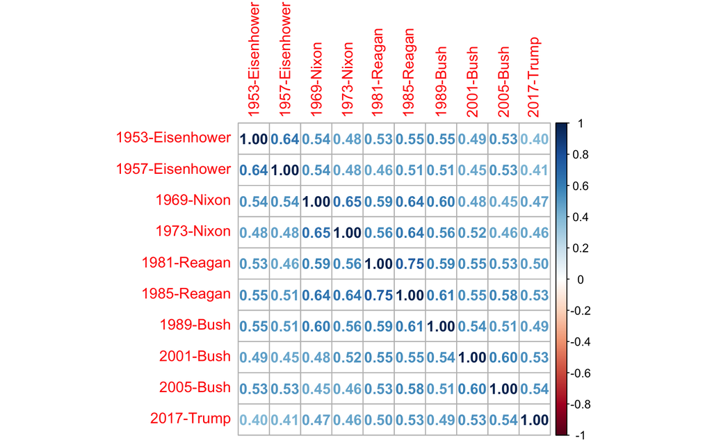

```r
GOP_cos_sim <- textstat_simil(GOP_dfm,
                             margin = "documents",
                             method = "cosine")
# plotting
library(corrplot)
## corrplot 0.92 loaded
GOP_cos_sim <-as.matrix(GOP_cos_sim)
corrplot(GOP_cos_sim, method = 'number')
```

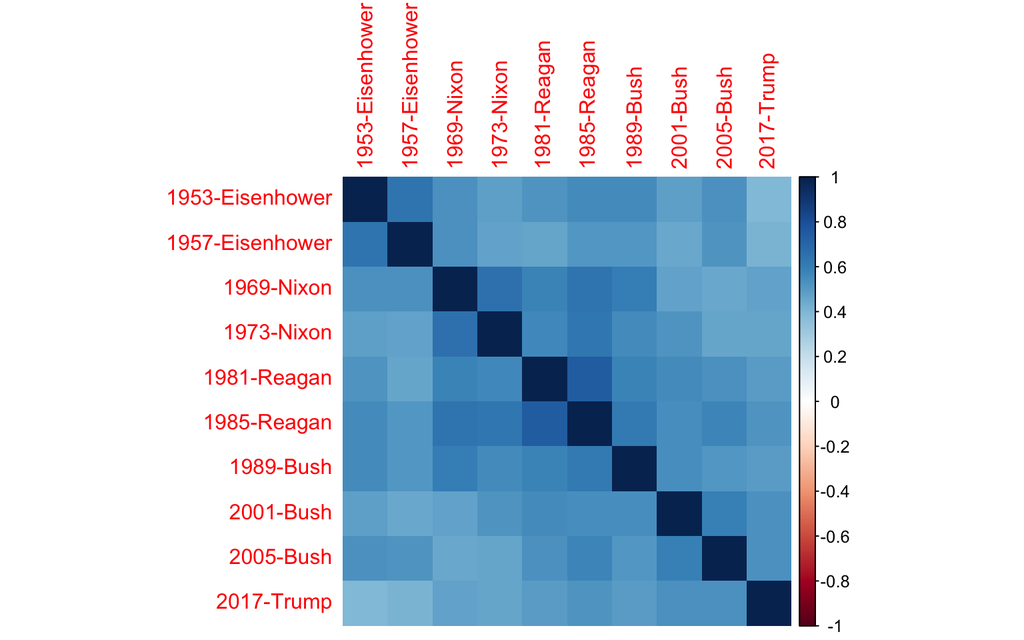

```r
corrplot(GOP_cos_sim, method = 'shade') # set `type = lower` for just lower half
```